# Suh_Assignment_8

### Yelp Business Reviews for

### geldata/edgedb

[figure not shown]

**Author: Atef Bader, PhD**  
**Last Edit: 5/19/2024**

**Revised by Tom Miller, 2/19/2023**  
**Revised by Edward Arroyo, 5/18/2024**

## Assignment Objectives:

- Create the Graph-Relational Data Model for Yelp data (Businesses and Reviews) of Chicago downtown area using the geldata/edgedb Schema Definition Language
- Query the Graph-Relational database using the geldata/edgedb for Yelp data (Businesses and Reviews) of Chicago downtown area

## Deliverables:

You are required to submit **three** files with the naming convention **LastName_Assignment_8** :

1. **IPYNB Script**: This is your original notebook file ( **LastName_Assignment_8.ipynb** ).
2. **HTML Document**: This file must include all the source code you have written along with its output. This should include your source code and output. Follow these steps to generate the HTML file:
   - After completing your work in the Jupyter Notebook, go to the menu bar at the top.
   - Click on File, then hover over Download as.
   - Select HTML (.html)
   - Save the file with the appropriate naming convention ( **LastName_Assignment_8.html** ).
   - **Ensure all code and outputs are properly displayed in the HTML document.**
3. **MP4 Video Recording:** A live demo recording lasting between 5 and 10 minutes.

**Note**: You are required to provide your code and its output immediately following each requirement for this assignment.

### General Assignment Instructions:

- Set up your working directory on your personal computer.
- Download the assignment notebook: `Chicago-Yelp-Reviews.ipynb` to your working directory.
- Install geldata/edgedb on your personal development computer by following the instructions at: https://docs.geldata.com/learn/installation.
- Create a Google Developer Account and obtain your `geocoder.ApiKey` for Google Maps.
- Navigate to your working directory from a console/terminal window.
- Run the provided Python script on your personal development computer to populate the geldata/edgedb database and perform analyses.

### geldata/edgedb Development & Build Instructions:

- From the assignment directory (containing `Chicago-Yelp-Reviews.ipynb`), execute the following commands to set up the geldata/edgedb database project and the database schema for the assignment:
  - To see where the gel/edgedb system files are located, use:
    - `gel info`
  - Ensure that the following files are in your working directory:
    - `dbschema/default.gel`
    - `gel.toml`
  - To initialize the database project, use:
    - `gel project init`
  - To verify that the project has been defined in the active working directory, use:
    - `gel project info`
  - To prepare for populating the database and running queries against it, use:
    - `gel migration create`
    - `gel migrate`
  - Note that there will now be a `dbschema/migrations` subdirectory containing a query file with the `.edgeql` extension, for example:
    - `00001.edgeql`
  - To check information about the database structure you have defined, use:
    - `gel list types`
  - To explore the unpopulated database structure with a graphical user interface (GUI) (and later to explore the populated gel/edgedb database), use:
    - `gel ui`
  - If you need help with the geldata/edgedb Command Line Interface (CLI), use:
    - `gel help`

### Configure Instance Authentication via gel UI:

- After exploring the gel UI, open the REPL within the UI to execute configuration commands:
  - In the gel UI, find and open the "REPL" or "Console" to access the command interface.
  - Paste and execute the following EdgeQL command to configure instance authentication for passwordless access:

    ```
    edgeql
    configure instance insert Auth {
        # Human-oriented comment helps figuring out
        # what authentication methods have been setup
        # and makes it easier to identify them.
        comment := 'passwordless access',
        priority := 1,
        method := (insert Trust),
    };
    ```

  - This command sets up an authentication method allowing passwordless access, useful for development environments or specific secure contexts. Ensure this configuration aligns with your security and operational policies.

## Online Educational Resources and References

The following is a list of available Online Education Resources and References for geldata/edgedb, Graph Databses, and Yelp graph data model. Some of the refernces are discussed within the context of **Neo4J** graph database, however, please note that this assignment requires the use of **geldata/edgedb**

- Graph Data Modeling Tips & Tricks
- https://www.youtube.com/watch?v=eAbPgyouAE4
- Predicting Influence and Communities Using Graph Algorithms
- https://www.youtube.com/watch?v=MTnozZ5Cy0E
- Exploring Yelp with Graph Algorithms (Neo4j Online Meetup #45)
- https://www.youtube.com/watch?v=7f2Tdn94JhY&t=1105s
- Yelp Data Analysis [Part 1]
- https://www.youtube.com/watch?v=3KX41CaJVpY
- Graph Algorithms: Practical Examples in Apache Spark & Neo4j
- https://neo4j.com/press-releases/new-oreilly-graph-algorithms-book/

[figure not shown]

# geldata/edgedb

- Getting Started with **[geldata](https://docs.geldata.com/)**
- Quick Start with **[Quickstart](https://docs.geldata.com/learn/quickstart/overview/nextjs)**
- Data modeling in geldata/edgedb **[Data Model](https://www.geldata.com/showcase/data-modeling)**
- geldata/edgedb’s Schema Definition Language **[ESDL](https://docs.geldata.com/reference/datamodel)**

## The three major platofrms are supported:

1. Windows
2. MacOS
3. Linux

## geldata/edgedb instance

- Make sure to initialize your geldata/edgedb project from your current project directory and type from the terminal/command prompt the following command:
  - gel project init

## geldata/edgedb Migration

- After you update your default.esdl in your current project **dbschema** directory, execute from the terminal/command prompt the following commands in the sequence listed below:
  - gel migration create
  - gel migrate

## geldata/edgedb Instance Destroy

- Once your are done coding/testing, you could get a list of geldata/edgedb instance names and destroy/kill them using the following commands:
  - gel instance list
  - gel instance destroy -I "your_instance_name" --force

## gel UI

- You can use the **gel UI**, the admin dashboard baked into every geldata/edgedb instance when you are instrumenting with your queries and requirements
- Type the following command from a terminal/window to start the geldata/edgedb ui in a browser:
  - gel ui

## EdgeQL

- https://www.geldata.com/docs/edgeql/index

# Yelp

- The graph data model has been discussed in Chapter 7 of in this book __ [Graph Algorithms — Practical Examples in Apache Spark & Neo4J](https://neo4j.com/books/free-book-graph-algorithms-practical-examples-in-apache-spark-and-neo4j/).
- However, in this Assignment we want to use **Community Areas** to track businesses and their reviews

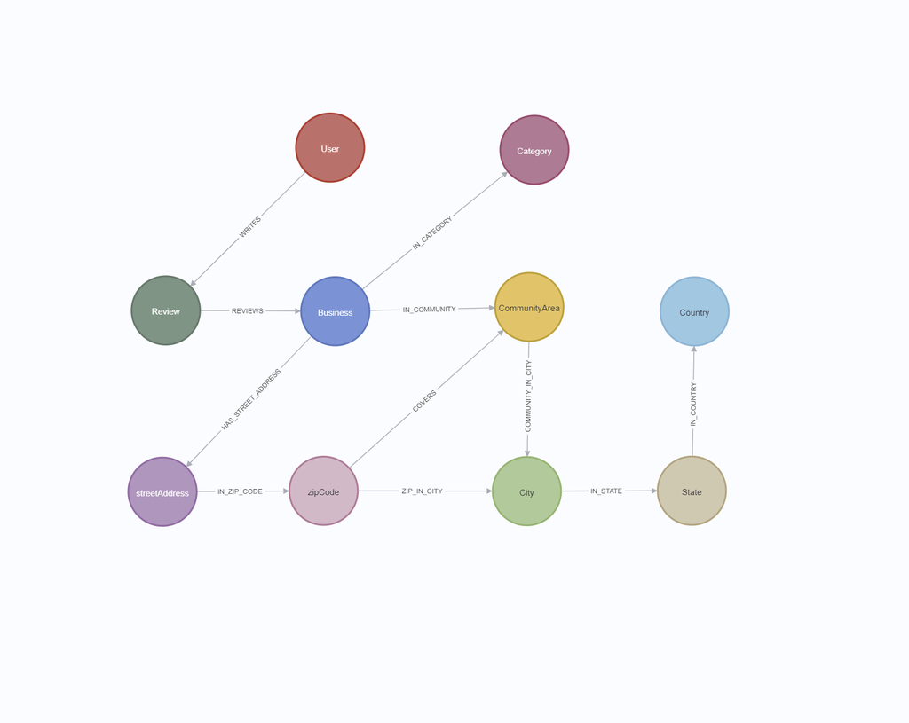

### Yelp Datasets (Businesses and Reviews) are documented in detail at the following URL:

- https://www.yelp.com/dataset/documentation/main

Please note that the dataset we use for this script is collected using **YELP Fusion API** rather than their online datasets for the purposes of this project

### Our Chicago Yelp Reviews Datasets (Businesses and Reviews) are composed of two JSON files:

- **chicago_yelp_reviews.json** : it has the businesses reviewed for Chicago Downtown Area
- **chicago_business_reviews.json** : it has 3 review excerpts collected from Yelp for every reviewed business in Chicago Downtown Area

**Note:** the business_id is the common attribute/field between the two datasets.

### Here is the official URL for Yelp Fusion API docs:

- https://docs.developer.yelp.com/docs/fusion-intro
- https://docs.developer.yelp.com/reference/v3_business_search
- https://docs.developer.yelp.com/reference/v3_business_reviews

### Use Yelp Fusion API to search for:

- Businesses:
  - This endpoint returns up to 1000 businesses with some basic information based on the provided search criteria.
    - https://docs.developer.yelp.com/reference/v3_business_search
- Reviews:
  - This endpoint returns up to three review **excerpts** for a given business
    - https://www.yelp.com/developers/documentation/v3/business_reviews
- Location:
  - Please make a note of the following **"Businesses returned in the response may not be strictly within the specified location"** in the highlighted text of Yelp API business_seach documentation for **location**

[figure not shown]

# Yelp Reviews for Chicago Businesses

We are interested to collect data about Chicago businesses and their Reviews from Yelp.

Currently the API give back 3 reviews for every business using the **business_reviews** endpoint, but we have the average stars rating and counts of the reviews for every business given in the **business_search** endpoint.

# Why use Yelp data?

Imagine you are visiting Chicago for the first time and you like to get an idea about popular restaurants that serve Chicago-Style Food?

- Chicago Style Hotdogs
- Chicago Style Pizza

# Nature of Collected Data and Dirty Data

When you construct your Data Model in geldata/edgedb and use gel UI to explore the populated data, please make a note of the following

- Chain restaurants like McDonalds might appear multiple times as a business, however, the street address and Latitude/Longitude pairs MUST be different
- If you get TWO or MORE businesses in the SAME Address, it is due to the fact that one business is still open in that address, however, the other business names show those businesses are closed currently and they used to occupy that same address before
- Not all Latitude/Longitude pairs are mapped correctly to their perspective community areas and that is due to the fact the Google Geocoder/reverse lookup couldn't find the correct community area and it maps/defaults the community area name to "Chicago"

### Here are the URLs for Yelp Fusion API and YelpAPI package:

Here are the URLs for the **Yelp Fusion API** and **YelpAPI Package**:

- Get started with the **Yelp Fusion API**
  - https://docs.developer.yelp.com/docs/fusion-intro
- Extensive list of search **parameters** using Endpoint /businesses/search
  - https://www.yelp.com/developers/documentation/v3/business_search
- Example how to use **Yelp Fusion API** Endpoint
  - https://github.com/Yelp/yelp-fusion/blob/master/fusion/python/sample.py
- Example how to use **YelpAPI Package** Endpoint
  - https://github.com/lanl/yelpapi/
  - https://www.yelp.com/developers/documentation/v3/business_search

# Chicago Community Areas

We are interested in the community areas of downtown chicago:

- Chicago Loop
- West Town
- Near North Side Chicago
- Near South Side Chicago
- Near West Side Chicago

You can see the official list for the Boundaries of different Community Areas at the following URL:

- https://data.cityofchicago.org/Facilities-Geographic-Boundaries/Boundaries-Community-Areas-current-/cauq-8yn6

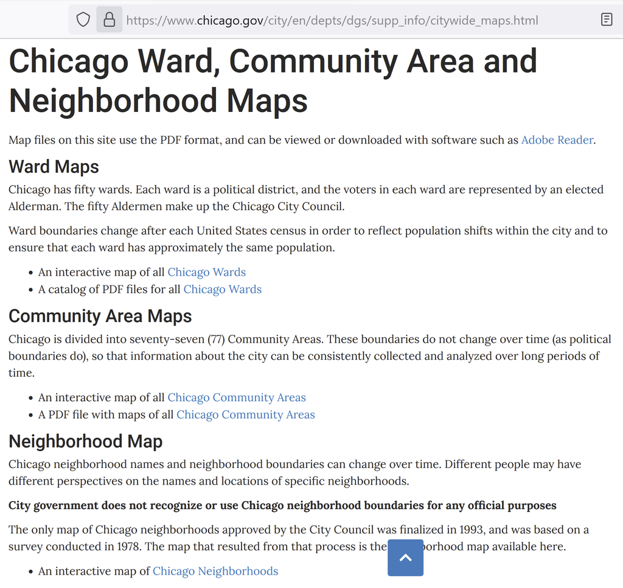

#### Google Developer Account

- You need to have a Google Developer account and Geocoder API key in order to do reverse lookup latitiude/logitude to cross-reference Address/Zip-Code/Community Area
- Create Google Developer Account and get your geocoder.ApiKey from the following URL: https://developers.google.com/maps/documentation/geocoding/get-api-key
- Add your geocoder.ApiKey = "ADD-YOUR-API-KEY-HERE"
- Use the latitude and longitude in geocoder.GeocodingReverse to find the zip-code
- Docuemntation about the Geocoder here: (https://geocoder.readthedocs.io/providers/Google.html#geocoding)

```python
from pprint import pprint
import datetime
import gel
import time
import warnings
warnings.filterwarnings('ignore')
```

### Business Categories

There are certain categories that are recognized by Yelp and accordingly index their reviews.

Visit the following URL to see the list:

- https://docs.developer.yelp.com/docs/resources-categories
- https://docs.developer.yelp.com/reference/v3_all_categories

For **Chicago Businesses**, we will collect businesses in the following categories

- Restaurants
- Entertainment
- Nightlife

```python
import pandas as pd
import json

df__business_reviews = pd.DataFrame()

list__business_reviews_documents = []
```

## Chicago Downtown Neighborhoods and Zip-Codes

- **The following zip codes for Chicago downtown area and neighborhoods**
- **Visit the following website for complete list of Chicago zip-codes for Chicago downtown area**

(https://www.seechicagorealestate.com/chicago-zip-codes-by-neighborhood.php)

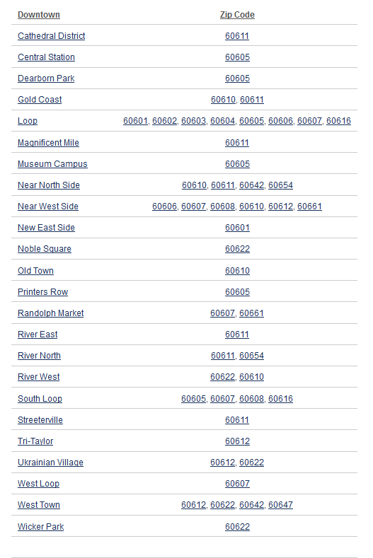

- **The following URL has the complete list of the 77 Community Areas for the City of Chicago**

( https://en.wikipedia.org/wiki/Community_areas_in_Chicago )

[figure not shown]

# Dataset #1 to Build the Database

### Read the provided chicago_yelp_reviews.json dataset and load into a dataframe object

### The dataset has the businesses reviewed on Yelp for the Chicago Downtown area

```python
# Load the JSON data from a file
file_path = 'chicago_yelp_reviews.json'

# Open the file and read line by line
with open(file_path, 'r') as file:
    for line in file:
        # Parse each line as JSON and append to the list
        list__business_reviews_documents.append(json.loads(line))

# Convert the list of dictionaries to a DataFrame
df= pd.DataFrame(list__business_reviews_documents)


source_df = pd.json_normalize(df['source'])


df_businesses = df.drop(columns=['id','source']).join(source_df)
```

```python
# Display the business info DataFrame
df_businesses.tail()
```

|  | id | alias | name | image_url | is_closed | url | review_count | categories | rating | transactions | ... | coordinates.latitude | coordinates.longitude | location.address1 | location.address2 | location.address3 | location.city | location.zip_code | location.country | location.state | location.display_address |
| --- | --- | --- | --- | --- | --- | --- | --- | --- | --- | --- | --- | --- | --- | --- | --- | --- | --- | --- | --- | --- | --- |
| 1996 | mhfLifyOVfK8VbUwMNH7TQ | ketel-one-club-chicago | Ketel One Club | https://s3-media4.fl.yelpcdn.com/bphoto/9Jx3NA... | False | https://www.yelp.com/biz/ketel-one-club-chicag... | 16 | [{'alias': 'tradamerican', 'title': 'American'}] | 3.0 | [] | ... | 41.881195 | -87.674409 | 1901 W Madison St |  | The United Center | Chicago | 60612 | US | IL | [1901 W Madison St, The United Center, Chicago... |
| 1997 | qZsUJ3WRVbSkM-lWO5LVoA | shehed-bakery-chicago-2 | Shehed Bakery | https://s3-media1.fl.yelpcdn.com/bphoto/inY_YC... | False | https://www.yelp.com/biz/shehed-bakery-chicago... | 1 | [{'alias': 'bakeries', 'title': 'Bakeries'}, {... | 4.0 | [] | ... | 41.883983 | -87.705639 | 135 N Kedzie Ave | None | None | Chicago | 60612 | US | IL | [135 N Kedzie Ave, Chicago, IL 60612] |
| 1998 | j5wLsTnvuD1voV9W0Dl32Q | sbarro-chicago-15 | Sbarro | https://s3-media2.fl.yelpcdn.com/bphoto/6KPDZG... | False | https://www.yelp.com/biz/sbarro-chicago-15?adj... | 1 | [{'alias': 'pizza', 'title': 'Pizza'}] | 4.0 | [delivery] | ... | 41.871316 | -87.669862 | 1717 W Polk St | None | None | Chicago | 60612 | US | IL | [1717 W Polk St, Chicago, IL 60612] |
| 1999 | I37aZuiMpvQvQDJFkzZxnQ | tempesta-chicago-2 | Tempesta | https://s3-media4.fl.yelpcdn.com/bphoto/dXaEHU... | False | https://www.yelp.com/biz/tempesta-chicago-2?ad... | 1 | [{'alias': 'italian', 'title': 'Italian'}] | 4.0 | [delivery, pickup] | ... | 41.891170 | -87.661817 | 433 W Van Buren St |  | None | Chicago | 60607 | US | IL | [433 W Van Buren St, Chicago, IL 60607] |
| 2000 | wZrd1D_bIHpe1wM-JvbznQ | hawkeyes-bar-and-grill-chicago | Hawkeye's Bar & Grill | https://s3-media3.fl.yelpcdn.com/bphoto/Ygph77... | False | https://www.yelp.com/biz/hawkeyes-bar-and-gril... | 368 | [{'alias': 'sportsbars', 'title': 'Sports Bars... | 3.0 | [delivery, pickup] | ... | 41.869484 | -87.663926 | 1458 W Taylor St |  |  | Chicago | 60607 | US | IL | [1458 W Taylor St, Chicago, IL 60607] |

5 rows × 24 columns

```python
df_businesses.describe()
```

|  | review_count | rating | distance | coordinates.latitude | coordinates.longitude |
| --- | --- | --- | --- | --- | --- |
| count | 2001.000000 | 2001.000000 | 2001.000000 | 2001.000000 | 2001.000000 |
| mean | 215.496252 | 3.927886 | 1203.364428 | 41.880323 | -87.640107 |
| std | 529.505377 | 0.696399 | 797.907298 | 0.020229 | 0.016972 |
| min | 1.000000 | 1.000000 | 19.911342 | 41.830179 | -87.706481 |
| 25% | 12.000000 | 3.500000 | 612.860415 | 41.869080 | -87.648830 |
| 50% | 56.000000 | 4.000000 | 1014.525707 | 41.881100 | -87.634410 |
| 75% | 217.000000 | 4.400000 | 1761.269317 | 41.886540 | -87.628345 |
| max | 10096.000000 | 5.000000 | 5453.081964 | 41.927330 | -87.606944 |

## Chicago-Style Food

Chicago is renowned for its **Chicago-style deep-dish pizza**, and you can learn more about the origins of this term by reading the Chicago Tribune article available at [this link](https://www.chicagotribune.com/news/ct-xpm-2009-02-18-0902180055-story.html). However, Chicago's culinary fame doesn't stop there; the city is also known for its Chicago-style hot dogs, which you can read about on [Wikipedia](https://en.wikipedia.org/wiki/Chicago-style_hot_dog).

Visitors to Chicago often seek to experience these two iconic dishes that bear the city's culinary signature:

- Pizza
- Hot Dogs

For illustration purposes, let's consider the following two famous restaurants in downtown Chicago:

- Portillo's - Known for Chicago-Style Hot Dogs
- Giordano's - Renowned for Chicago-Style Pizza

**Note 1:** Some business names may appear multiple times, which could lead to the mistaken belief that the dataset contains redundant entries. However, this is not the case, as a restaurant chain might use the same business name for different locations, a detail that is captured under the alias field.

Here is an example for Potbelly Sandwich Shop:

- 'alias': 'potbelly-sandwich-shop-chicago-25'
- 'name': 'Potbelly Sandwich Shop'
- 'alias': 'potbelly-sandwich-shop-chicago-10'
- 'name': 'Potbelly Sandwich Shop'

**Note 2:** Yelp reviews may refer to business names with or without an **s** at the end. For example, you might see reviews mentioning the business names either as "Portillo's" or "Portillo" and "Giordano's" or "Giordano".

```python
df_businesses.name.value_counts()
```

```
name
Starbucks                42
Dunkin'                  27
Subway                   17
7-Eleven                 15
Jimmy John's             14
                         ..
Momentum Coffee           1
Veggie House              1
Daifuku Ramen             1
3 Little Pigs Chi         1
Hawkeye's Bar & Grill     1
Name: count, Length: 1729, dtype: int64
```

```python
print(len(list__business_reviews_documents))
pprint(list__business_reviews_documents[:5])
```

```
2001
[{'id': 'lxE3OEbLWnGP1pUrNzlgEw',
  'source': {'alias': 'maggie-roeder-cakes-chicago',
             'categories': [{'alias': 'desserts', 'title': 'Desserts'}],
             'coordinates': {'latitude': 41.88626, 'longitude': -87.62231},
             'display_phone': '',
             'distance': 324.6541824855661,
             'id': 'lxE3OEbLWnGP1pUrNzlgEw',
             'image_url': 'https://s3-media1.fl.yelpcdn.com/bphoto/kCFZvtk9jrqmj6DYqAcKaA/o.jpg',
             'is_closed': False,
             'location': {'address1': '',
                          'address2': '',
                          'address3': '',
                          'city': 'Chicago',
                          'country': 'US',
                          'display_address': ['Chicago, IL 60601'],
                          'state': 'IL',
                          'zip_code': '60601'},
             'name': 'Maggie Roeder Cakes',
             'phone': '',
             'price': '$$',
             'rating': 5.0,
             'review_count': 6,
             'transactions': [],
             'url': 'https://www.yelp.com/biz/maggie-roeder-cakes-chicago?adjust_creative=j_3xxHM_fKdWcYKUO806vA&utm_campaign=yelp_api_v3&utm_medium=api_v3_business_search&utm_source=j_3xxHM_fKdWcYKUO806vA'}},
 {'id': 'A_MAASk8gTKs9pxncdQ8pQ',
  'source': {'alias': 'rhoyal-decadence-chicago',
             'categories': [{'alias': 'desserts', 'title': 'Desserts'}],
             'coordinates': {'latitude': 41.8768186986257,
                             'longitude': -87.634513006543},
             'display_phone': '(312) 857-8336',
             'distance': 1283.8743938407906,
             'id': 'A_MAASk8gTKs9pxncdQ8pQ',
             'image_url': 'https://s3-media1.fl.yelpcdn.com/bphoto/aj6XOhAlpsk4S2v7GA5YmQ/o.jpg',
             'is_closed': False,
             'location': {'address1': '',
                          'address2': '',
                          'address3': '',
                          'city': 'Chicago',
                          'country': 'US',
```

[output cut: 76 more lines]

```
                          'address2': None,
                          'address3': '',
                          'city': 'Chicago',
                          'country': 'US',
                          'display_address': ['224 S Michigan Ave Chicago Il '
                                              '60604',
                                              'Chicago, IL 60604'],
                          'state': 'IL',
                          'zip_code': '60604'},
             'name': 'Mindworks',
             'phone': '+17737954580',
             'rating': 5.0,
             'review_count': 10,
             'transactions': [],
             'url': 'https://www.yelp.com/biz/mindworks-chicago-2?adjust_creative=j_3xxHM_fKdWcYKUO806vA&utm_campaign=yelp_api_v3&utm_medium=api_v3_business_search&utm_source=j_3xxHM_fKdWcYKUO806vA'}}]
```

# Dataset #2 to Build the Database

### Read the provided chicago_business_reviews.json dataset and load into a dataframe object

### The dataset has 3 review excerpts collected from Yelp for every business reviewed in the Chicago Downtown area

```python
# Path to the business reviews JSON file
business_reviews_json_file_path = 'chicago_business_reviews.json'

# Read the business reviews from JSON file into a DataFrame
df__business_reviews = pd.read_json(business_reviews_json_file_path , orient='records', lines=True)
```

```python
df__business_reviews.tail()
```

|  | id | url | text | rating | time_created | user | business_id | business_name |
| --- | --- | --- | --- | --- | --- | --- | --- | --- |
| 5666 | ZgxSQmsTNfupRNzVsODVDg | https://www.yelp.com/biz/ketel-one-club-chicag... | Great service!!!!!! Amazingly kind staff, gre... | 5 | 2023-04-08 06:41:33 | {'id': '4fqk_SfYUfs8jghF8Qn29g', 'profile_url'... | mhfLifyOVfK8VbUwMNH7TQ | Ketel One Club |
| 5667 | 1hSNJYRqPpBpuXwjGOJQaA | https://www.yelp.com/biz/ketel-one-club-chicag... | Sat there for 30 minutes couldn't even get a w... | 1 | 2023-02-02 20:01:48 | {'id': 'y-Gxjq9v0fh81yWweEYkIA', 'profile_url'... | mhfLifyOVfK8VbUwMNH7TQ | Ketel One Club |
| 5668 | UvQxUOCYAW3WCx64yHh8qw | https://www.yelp.com/biz/shehed-bakery-chicago... | I stumbled upon this company at an artisan mar... | 4 | 2023-12-03 19:41:12 | {'id': 's-yGhMIJTcW39FTTzc2_Eg', 'profile_url'... | qZsUJ3WRVbSkM-lWO5LVoA | Shehed Bakery |
| 5669 | oNW8CABLe8jcNLaWOk-0QQ | https://www.yelp.com/biz/sbarro-chicago-15?adj... | Quick Tip! Some sbarros sell breakfast. Typi... | 4 | 2023-06-26 06:19:18 | {'id': 'nJ6c6Tcg7e5vpOdQa8mdqQ', 'profile_url'... | j5wLsTnvuD1voV9W0Dl32Q | Sbarro |
| 5670 | lpLyqXwKXCaaR6R8OVcVcw | https://www.yelp.com/biz/tempesta-chicago-2?ad... | Visited Tempesta today for a quick lunch takeo... | 4 | 2022-06-21 10:10:46 | {'id': '488KrW58ryVduy0Me8DRxg', 'profile_url'... | I37aZuiMpvQvQDJFkzZxnQ | Tempesta |

#### Geocoder API key -

- In order get the complete address that has community area name , you need to use Geocoder API and do reverse lookup on lat/lng. That is use latitude/logitude to cross-reference Address/Zip-Code/Community Area
- You need to have a Google Developer account to use Geocoder API key in order to do reverse lookup on lat/lng
- Create Google Developer Account and get your geocoder.ApiKey from the following URL: https://developers.google.com/maps/documentation/geocoding/get-api-key
- Add your geocoder.ApiKey = "ADD-YOUR-API-KEY-HERE"
- Use the latitude and longitude in geocoder.GeocodingReverse to find the zip-code
- Docuemntation about the Geocoder here: (https://geocoder.readthedocs.io/providers/Google.html#geocoding)

#### Geocoder API Key -

- To obtain the complete address, including the community area name, you need to use the Geocoder API for reverse lookup based on latitude and longitude. This means using latitude and longitude to cross-reference the Address, Zip Code, and Community Area.
- A Google Developer account is required to use the Geocoder API key for reverse lookup on latitude and longitude.
- Create a Google Developer Account and obtain your geocoder.ApiKey from the following URL: https://developers.google.com/maps/documentation/geocoding/get-api-key
- Add your geocoder.ApiKey = "ADD-YOUR-API-KEY-HERE".
- Use the latitude and longitude in `geocoder.GeocodingReverse` to find the zip code.
- Documentation about the Geocoder can be found here: https://geocoder.readthedocs.io/providers/Google.html#geocoding

#### Important Warning:

- Please be aware that while Google offers a free tier for its Geocoder API, charges may apply if you exceed the free usage limit. Google requires credit card information even for the free trial. Ensure you monitor your usage to avoid unexpected charges.

## Installing the Geocoder Package

In the given code snippet, we're using a method to install the `geocoder` package directly within our Jupyter Notebook. This is particularly useful for ensuring that the package is installed to the correct Python environment associated with the notebook's kernel.

```python
!pip install geocoder
```

# IMPORTANT Note

### Community Area Name vs. Neighborhood Name:

- City of Chicago acknowledges the presence of Neighborhood names but they do NOT use them for official business
- City of Chicago uses Community Area Names and Numbers for doing business
- Google Geocoder uses Neighborhood Name type to represent Community Area Name

See below an example

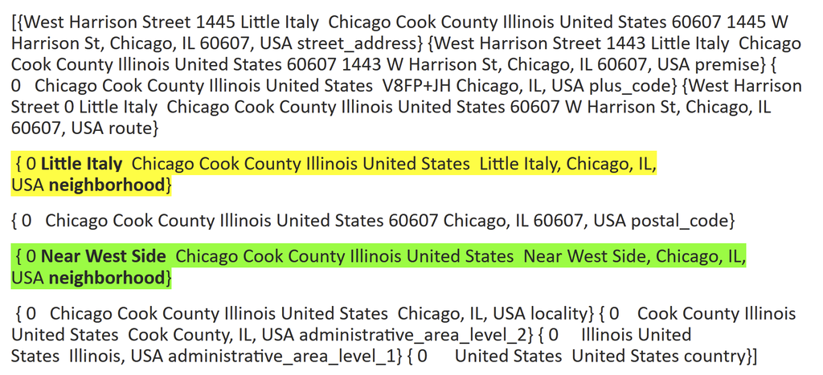

#### Use the geldata/edgedb Graphical User Interface (GUI) to Trace Your Progress -

Having initialized an geldata/edgedb instance and project, we should be able to trace our progress in populating that database. A good way to do this is to open the geldata/edgedb GUI and refer to it as we do our work with this Python script, gathering restaurant review data from Yelp and geocoding street addresses with the help of Google.

From the working project directory enter this command: - gel ui

Before we populate the database, we will see that there are 10 object types but a count of zero objects. The schema has been defined, but there are no data in the database.

```python
# Sample code snippet to show you how you can do Geocoder Reverse Lookup

import geocoder
import requests
import json
import os  # Import the os module
from dotenv import load_dotenv  # Import the load_dotenv function

load_dotenv()


geocoder.ApiKey = os.getenv("GEOCODE_API_KEY")



# Sanity test your API Key for Girdano'S Pizza on Rush street in downtown; it should show you Chicago Loop Neighborhood
# something like this:
# " .... {'long_name': 'Chicago Loop', 'short_name': 'Chicago Loop', 'types': ['neighborhood', 'political']}, .... "

latitude_str = str(41.8840343)
longitude_str = str(-87.628081)


url = 'https://maps.googleapis.com/maps/api/geocode/json?latlng='+latitude_str+','+longitude_str+'&key='+geocoder.ApiKey
response = requests.get(url).json()

print(response)
for item in response['results']:
    pprint(item)
```

```
{'plus_code': {'compound_code': 'V9MC+JQ7 Chicago, IL, USA', 'global_code': '86HJV9MC+JQ7'}, 'results': [{'address_components': [{'long_name': 'Washington', 'short_name': 'Washington', 'types': ['establishment', 'point_of_interest', 'subway_station', 'transit_station']}, {'long_name': 'Chicago Loop'…
{'address_components': [{'long_name': 'Washington',
                         'short_name': 'Washington',
                         'types': ['establishment',
                                   'point_of_interest',
                                   'subway_station',
                                   'transit_station']},
                        {'long_name': 'Chicago Loop',
                         'short_name': 'Chicago Loop',
                         'types': ['neighborhood', 'political']},
                        {'long_name': 'Chicago',
                         'short_name': 'Chicago',
                         'types': ['locality', 'political']},
                        {'long_name': 'Cook County',
                         'short_name': 'Cook County',
                         'types': ['administrative_area_level_2', 'political']},
                        {'long_name': 'Illinois',
                         'short_name': 'IL',
                         'types': ['administrative_area_level_1', 'political']},
                        {'long_name': 'United States',
                         'short_name': 'US',
                         'types': ['country', 'political']},
                        {'long_name': '60602',
                         'short_name': '60602',
                         'types': ['postal_code']}],
 'formatted_address': 'Washington, Chicago, IL 60602, USA',
 'geometry': {'location': {'lat': 41.88372690000001, 'lng': -87.6292991},
              'location_type': 'GEOMETRIC_CENTER',
              'viewport': {'northeast': {'lat': 41.88507588029151,
                                         'lng': -87.62795011970849},
                           'southwest': {'lat': 41.88237791970851,
                                         'lng': -87.6306480802915}}},
 'navigation_points': [{'location': {'latitude': 41.8840634,
                                     'longitude': -87.6279975}},
                       {'location': {'latitude': 41.8837072,
                                     'longitude': -87.629486}},
                       {'location': {'latitude': 41.8837404,
                                     'longitude': -87.6295674},
                        'restricted_travel_modes': ['DRIVE']},
                       {'location': {'latitude': 41.8832015,
```

[output cut: 307 more lines]

```
                                         'lng': -91.51307899999999}}},
 'place_id': 'ChIJGSZubzgtC4gRVlkRZFCCFX8',
 'types': ['administrative_area_level_1', 'political']}
{'address_components': [{'long_name': 'United States',
                         'short_name': 'US',
                         'types': ['country', 'political']}],
 'formatted_address': 'United States',
 'geometry': {'bounds': {'northeast': {'lat': 74.071038, 'lng': -66.885417},
                         'southwest': {'lat': 18.7763, 'lng': 166.9999999}},
              'location': {'lat': 38.7945952, 'lng': -106.5348379},
              'location_type': 'APPROXIMATE',
              'viewport': {'northeast': {'lat': 74.071038, 'lng': -66.885417},
                           'southwest': {'lat': 18.7763, 'lng': 166.9999999}}},
 'place_id': 'ChIJCzYy5IS16lQRQrfeQ5K5Oxw',
 'types': ['country', 'political']}
```

### Use geldata/edgedb to create the object graph relational database for Yelp Reviews for Chicago Businesses

You need to store the **Businesses** and their **Reviews** considering the data model listed above. We don't have access to Yelp endpoint for **users**, but we do have Yelp endpoints **Businesses** and their **Reviews**

Here is the link for the API documentation:

- https://docs.developer.yelp.com/reference/v3_business_search

# Requirements Specification:

```python
import gel
```

### Requirement 1:

- Create a Graph-Relational Data Model for Yelp Businesses/Reviews using **geldata/edgedb**.
- Insert the YELP REVIEW objects into the geldata/edgedb database.

Consider the following code snippet for your schema:

```
module default {
    type Country {
        property name -> str;
        multi link has_states := .<in_country[is State];
        constraint exclusive on (.name);
    }

    type State {
        property name -> str;
        link in_country -> Country;
        multi link has_cities := .<in_state[is City];
        constraint exclusive on ((.name, .in_country));
    }

    type City {
        property name -> str;
        link in_state -> State;
        multi link has_communityAreas := .<in_city[is CommunityArea];
        multi link has_zipCodes := .<in_city[is ZipCode];
        constraint exclusive on ((.name, .in_state));
    }

    type CommunityArea {
        property name -> str;
        link in_city -> City;
        link has_zipcodes := .<in_communityArea[is ZipCode];
        multi link has_businesses := .<in_communityArea[is Business];
        constraint exclusive on ((.name, .in_city));
    }

    type ZipCode {
        property digits -> str;
        link in_city -> City;
        multi link in_communityArea -> CommunityArea;
        multi link has_streetAddresses := .<in_zipcode[is StreetAddress];
        constraint exclusive on (.digits);
    }

    type StreetAddress {
        property address1 -> str;
        property address2 -> str;
        property address3 -> str;
        link in_zipcode -> ZipCode;
        property coordinates -> tuple<latitude: float32, longitude: float32>;
        link has_business := .<has_address[is Business];
        constraint exclusive on (.coordinates);
    }

    type Business {
        property ID -> str;
        property name -> str;
        property alias -> str;
        property rating -> float32;
        property review_count -> int32;
        link in_communityArea -> CommunityArea;
        property coordinates -> tuple<latitude: float32, longitude: float32>;
        link has_address -> StreetAddress;
        multi link in_category -> Category;
        multi link has_reviews := .<reviews_business[is Review];
        constraint exclusive on (.ID);
    }

    type Category {
        property name -> str;
        link has_business := .<in_category[is Business];
        constraint exclusive on (.name);
    }

    type Review {
	    property review_id -> str;
        property text -> str;
        property rating -> float32;
        property time_created -> str;
        link reviews_business -> Business;
        link written_by -> User;
    }

    type User {
        property user_id -> str;
        multi link reviews := .<written_by[is Review];
        constraint exclusive on (.user_id);
    }
}
```

# Build the Database

- The following code will insert the objects into the database.
- It takes roughly 30 minutes to insert all objects for 2000 business with 3 reviews for evey business into the database.

[figure not shown]

```python
client = gel.create_client()

# Consider the following code snippet

# for review in final__list_business_reviews_documents:
# INSERT BusinessReviewsObject ...
count = 0
IDs = []
chicago_community_areas = ["Rogers Park", "West Ridge", "Uptown", "Lincoln Square", "North Center", "Lake View", "Lincoln Park", "Chicago Loop", "Near North Side", "Edison Park", "Norwood Park", "Jefferson Park", "Forest Glen", "North Park", "Albany Park", "Portage Park", "Irving Park", "Dunning", "Montclare", "Belmont Cragin", "Hermosa", "Avondale", "Logan Square", "Humboldt Park", "West Town", "Austin", "West Garfield Park", "East Garfield Park", "Near West Side", "North Lawndale", "South Lawndale", "Lower West Side", "The Loop", "Loop", "Near South Side", "Armour Square", "Douglas", "Oakland", "Fuller Park", "Grand Boulevard", "Kenwood", "Washington Park", "Hyde Park", "Woodlawn", "South Shore", "Chatham", "Avalon Park", "South Chicago", "Burnside", "Calumet Heights", "Roseland", "Pullman", "South Deering", "East Side", "West Pullman", "Riverdale", "Hegewisch", "Garfield Ridge", "Archer Heights", "Brighton Park", "McKinley Park", "Bridgeport", "New City", "West Elsdon", "Gage Park", "Clearing", "West Lawn", "Chicago Lawn", "West Englewood", "Englewood", "Greater Grand Crossing", "Ashburn", "Auburn Gresham", "Beverly", "Washington Heights", "Mount Greenwood", "Morgan Park", "O'Hare", "Edgewater"]


#While doing unit testing keep the min(500, len(list__business_reviews_documents)
#Once you complete unit testing change it to 2000 as follows: min(2000, len(list__business_reviews_documents)


for i in range(min(2000, len(list__business_reviews_documents))):
    review = list__business_reviews_documents[i]
    if review['id'] in IDs:
        continue
    IDs.append(review['id'])
    count += 1
    if count % 49 == 0:
        time.sleep(1)

    community_area = 'Chicago'
    categories = []
    if review['source']['coordinates']['latitude'] != None and review['source']['coordinates']['longitude'] != None:
        coordinates = (review['source']['coordinates']['latitude'], review['source']['coordinates']['longitude'])
    else:
        continue
    url = 'https://maps.googleapis.com/maps/api/geocode/json?latlng='+str(review['source']['coordinates']['latitude'])+','+str(review['source']['coordinates']['longitude'])+'&key='+geocoder.ApiKey
    response = requests.get(url, verify=False).json()

    if response['results']:
        if response['results'][0] != None:
            for item in response['results'][0]['address_components']:
                if 'neighborhood' in item['types'] and item['long_name'] in chicago_community_areas:
                    community_area = item['long_name']


        for category in review['source']['categories']:
            if category['title'] not in categories:
                categories.append(category['title'])
            client.query("""
                INSERT Category {
                    name := <str>$name
                } unless conflict on .name
            """, name=category['title'])

        client.query("""
            INSERT Country {
                name := <str>$name
            } unless conflict on .name
        """, name=review['source']['location']['country'])

        client.query("""
            INSERT State {
                name := <str>$name,
                in_country := (
                    select Country
                    filter
                        .name = <str>$country_name
                    limit 1
                )
            } unless conflict on (.name, .in_country)
        """, name=review['source']['location']['state'], country_name=review['source']['location']['country'])

        client.query("""
            INSERT City {
                name := <str>$name,
                in_state := (
                    select State
                    filter
                        .name = <str>$state_name
                    limit 1
                )
            } unless conflict on (.name, .in_state)
        """, name=review['source']['location']['city'], state_name=review['source']['location']['state'])

        client.query("""
            INSERT CommunityArea {
                name := <str>$name,
                in_city := (
                    select City
                    filter
                        .name = <str>$city_name
                    limit 1
                )
            } unless conflict on (.name, .in_city)
        """, name=community_area, city_name=review['source']['location']['city'])

        client.query("""
            INSERT ZipCode {
                digits := <str>$digits,
                in_city := (
                    select City
                    filter
                        .name = <str>$city_name
                    limit 1
                ),
                in_communityArea := (
                    select CommunityArea
                    filter
                        .name = <str>$community_area_name
                    limit 1
                )
            } unless conflict on .digits else (
                update ZipCode
                  set {
                    in_communityArea += (
                        select CommunityArea
                        filter
                            .name = <str>$community_area_name
                        limit 1
                    )
                  }
                )
        """, digits=review['source']['location']['zip_code'], city_name=review['source']['location']['city'], community_area_name=community_area)

        client.query("""
            INSERT StreetAddress {
                address1 := <str>$address1,
                address2 := <str>$address2,
                address3 := <str>$address3,
                coordinates := """ + str(coordinates) + """,
                in_zipcode := (
                    select ZipCode
                    filter
                        .digits = <str>$zip_code
                    limit 1
                )
            } unless conflict on .coordinates
        """, address1=review['source']['location']['address1'] if review['source']['location']['address1'] else '', address2=review['source']['location']['address2'] if review['source']['location']['address2'] else '', address3=review['source']['location']['address3'] if review['source']['location']['address3'] else '', zip_code=review['source']['location']['zip_code'])

        client.query("""
            INSERT Business {
                ID := <str>$id,
                name := <str>$name,
                alias := <str>$alias,
                rating := <float32>$rating,
                review_count := <int32>$review_count,
                coordinates := """ + str(coordinates) + """,
                in_communityArea := (
                    select CommunityArea
                    filter
                        .name = <str>$community_area_name
                    limit 1
                ),
                has_address := (
                    select StreetAddress
                    filter
                        .coordinates.latitude = <float32>$latitude and .coordinates.longitude = <float32>$longitude
                    limit 1
                ),
                in_category := (
                    select Category
                    filter
                        .name in array_unpack(<array<str>>$category_array)
                )
            } unless conflict on .ID
        """, id=review['id'], name=review['source']['name'], alias=review['source']['alias'], rating=review['source']['rating'], review_count=review['source']['review_count'], community_area_name=community_area, latitude=coordinates[0], longitude=coordinates[1], category_array=categories)

    business_reviews = df__business_reviews[df__business_reviews['business_id'] == review['id']]

    for _, business_review in business_reviews.iterrows():
        client.query("""
            INSERT User {
               user_id := <str>$user_id
            } unless conflict on .user_id
        """, user_id=business_review['user']['id'])

        client.query("""
                    INSERT Review {
                        review_id := <str>$review_id,
                        text := <str>$review_text,
                        rating := <float32>$rating,
                        time_created :=<str>$review_time_created,
                        reviews_business := (
                            SELECT Business
                            FILTER .ID = <str>$business_id
                            LIMIT 1
                        ),
                     written_by := (
                                SELECT User
                                FILTER .user_id = <str>$user_id
                                LIMIT 1
                            )
                    }
                """, review_id=business_review['id'], business_id=review['id'], review_text=business_review['text'], review_time_created=business_review['time_created'], rating=business_review['rating'], user_id=business_review['user']['id'])


client.close()
```

### Note:

- If there are no errors, that means the insertion of the objects is completed successfully by now.
- Verify objects inserted into the database using the geldata/edgedb UI.

Now is a good time to check the geldata/edgedb GUI (gel UI). You should notice that the object count is no longer zero.

For the remaining assignment requirements, we will use the Python gel/edgedb client to execute EdgeQL commands. Afterward, we can verify our work by comparing the results with those from the gel UI.

### Requirement 2:

- Write and execute an EdgeQL/Python code to retrieve all businesses with 5 stars from Yelp Graph-Relational Data Model you created in **Requirement 1**
- Compute the time it takes to execute this requirement with the Python EdgeQL client

```python
# Write your code here

client = gel.create_client()

# Consider the following code snippet

# Start the timer
start_time = time.time()

reviews_with_rating_5 = client.query('SELECT Business {name} FILTER .rating = <float32>$rating', rating = 5)

# Stop the timer
end_time = time.time()

# Calculate the elapsed time
elapsed_time = end_time - start_time

# Print the time needed to execute the requirement
print(f'\n\n\t\t Total Execution Time:  {elapsed_time:.2f} seconds \n\n')

for review in reviews_with_rating_5:
   print(review.name)

client.close()
```

```
		 Total Execution Time:  0.02 seconds


Maggie Roeder Cakes
Rhoyal Decadence
Miro Statue
TNS Pop Shop
Mindworks
Yelp Elite Battle Of The Band T's @ RAISED Urban Rooftop Bar
State Street, That Great Street
Auntie Anne's
Picasso Statue
7-Eleven
Marshall Field and Company Building
Brews & Bites
Ron Christian
Biker Dude
Cascade Park
Sneakerhead University
Farmer's Fridge
The Good Eating Company
Fashion Focus
Occupy Chicago
Field Museum Dig Site
Louise Nevelson's Dawn Shadows
Project Windows Design Contest
Washington-Morris-Salomon Monument
Marla's Mandel Bread
Chicago Temple Building
Flash UYE: Chicago Cultural Center
TourBound Golf Academy
TJ's Heavenly Sweet
Sweetling Cupcakes
Clark Johnson Orchestra
Wolverine Trading Kitchen
Porter's Steakhouse
The Flight of Daedalus and Icarus By Roger Brown 1991
The Member Bar at Terzo Piano
Wells Street Bridge
Chick-fil-A
```

[output cut: 115 more lines]

```
Embellish Kreations Decor
New Year's Day 2012 Idiot Swim
Dying to Survive
Stanton Park
StarChefs Chicago Rising Stars
Old Town
Event Espresso Catering
$5 Salad
The Wingout Festival
Cilantro Taco House Lincoln Park
Grapes Restaurant
Loud Mouth Food Bikes
Chicago  Artizen
Cuisines by Sammy
Zarsh Restaurant
```

### Requirement 3:

- Write and execute an EdgeQL/Python code to retrieve all businesses that offer **Pizza** in Zip-Code 60601 from Yelp Graph-Relational Data Model you created in **Requirement 1**
- Compute the time it takes to execute this requirement with the Python EdgeQL client

**Note:** If you don't get "Pizza" results for zip-code 60601, try any of the following zip codes(60602, 60603, 60604, 60605, 60606)

```python
import edgedb
import time


def find_pizza_restaurants():
    """
    Find pizza businesses in Chicago zip codes.
    """
    # Connect to database
    client = edgedb.create_client()

    # Chicago zip codes to search
    zip_codes = ['60601', '60602', '60603', '60604', '60605', '60606']
    category = 'Pizza'

    print(f"Looking for {category} businesses in Chicago zip codes...")
    print()

    # Start timing
    start_time = time.time()

    # Query to find pizza businesses
    query = """
        SELECT Business {
            name,
            rating,
            full_address := .has_address.address1 ++ ', ' ++
                           .has_address.in_zipcode.in_city.name ++ ', ' ++
                           .has_address.in_zipcode.in_city.in_state.name ++ ' ' ++
                           .has_address.in_zipcode.digits
        }
        FILTER
            EXISTS (SELECT .in_category FILTER .name = <str>$category)
            AND
            .has_address.in_zipcode.digits IN array_unpack(<array<str>>$zip_codes);
    """

    # Run the query
    results = client.query(query, category=category, zip_codes=zip_codes)

    # Stop timing
    end_time = time.time()
    total_time = end_time - start_time

    # Show results
    print(f"Found {len(results)} pizza businesses:")
    print()

    for business in results:
        print(f"- {business.name}")
        print(f"  Rating: {business.rating}")
        print(f"  Address: {business.full_address}")
        print()

    print(f"Query took {total_time:.3f} seconds")

    # Close connection
    client.close()


if __name__ == "__main__":
    find_pizza_restaurants()
```

```
Looking for Pizza businesses in Chicago zip codes...

Found 31 pizza businesses:

- Fontano's Subs and Pizzeria
  Rating: 4.099999904632568
  Address: 332 S Michigan Ave, Chicago, IL 60604

- Giordano's
  Rating: 3.9000000953674316
  Address: 130 E Randolph St, Chicago, IL 60601

- Giordano's - Jackson
  Rating: 3.799999952316284
  Address: 223 W Jackson Blvd, Chicago, IL 60606

- Exchequer Restaurant & Pub
  Rating: 3.799999952316284
  Address: 226 S Wabash Ave, Chicago, IL 60604

- The Florentine
  Rating: 3.700000047683716
  Address: 151 W Adams St, Chicago, IL 60603

- Luke's Italian Beef
  Rating: 3.700000047683716
  Address: 215 W Jackson Blvd, Chicago, IL 60606

- Millennium Hall
  Rating: 3.5
  Address: 11 N Michigan Ave, Chicago, IL 60602

- Pizano's Pizza & Pasta
  Rating: 3.4000000953674316
  Address: 61 E Madison St, Chicago, IL 60603

- Blaze Pizza
  Rating: 3.4000000953674316
  Address: 511 S State St, Chicago, IL 60605

```

[output cut: 74 more lines]

```
  Address: 1340 S Michigan, Chicago, IL 60605

- Aurelio's Pizza South Loop
  Rating: 3.5
  Address: 1212 S Michigan Ave, Chicago, IL 60605

- Sbarro
  Rating: 3.4000000953674316
  Address: 225 S Canal St, Chicago, IL 60606

- Armand's Pizzeria
  Rating: 2.700000047683716
  Address: 1416 South Michigan Ave, Chicago, IL 60605

Query took 0.052 seconds
```

### Requirement 4:

- Write and execute EdgeQL/Python code to retrieve the top 5 businesses with the highest number of reviews that offer **Hot Dogs** in Zip Code 60601, using the Yelp Graph-Relational Data Model you created in **Requirement 1**.
- Measure the execution time of this requirement using the Python EdgeQL client.

**Note:** If you don't get "Hot Dogs" results for zip-code 60601, try any of the following zip codes(60602, 60603, 60604, 60605, 60606)

```python
import edgedb
import time


def find_top_hotdog_businesses():
    """
    Find the top 5 Hot Dogs businesses by review count in Chicago zip codes.
    """
    # Connect to database
    client = edgedb.create_client()

    # Chicago zip codes to search
    zip_codes = ['60601', '60602', '60603', '60604', '60605', '60606']
    category = 'Hot Dogs'

    print(f"Looking for top 5 {category} businesses in Chicago zip codes...")
    print()

    # Start timing
    start_time = time.time()

    # Query to find Hot Dogs businesses
    query = """
        SELECT Business {
            name,
            review_count,
            rating,
            full_address := .has_address.address1 ++ ', ' ++
                           .has_address.in_zipcode.in_city.name ++ ', ' ++
                           .has_address.in_zipcode.in_city.in_state.name ++ ' ' ++
                           .has_address.in_zipcode.digits
        }
        FILTER
            EXISTS (SELECT .in_category FILTER .name = <str>$category)
            AND
            .has_address.in_zipcode.digits IN array_unpack(<array<str>>$zip_codes)
        ORDER BY .review_count DESC
        LIMIT 5;
    """

    # Run the query
    results = client.query(query, category=category, zip_codes=zip_codes)

    # Stop timing
    end_time = time.time()
    total_time = end_time - start_time

    # Show results
    print(f"Found {len(results)} Hot Dogs businesses:")
    print()

    for i, business in enumerate(results, 1):
        print(f"{i}. {business.name}")
        print(f"   Reviews: {business.review_count}")
        print(f"   Rating: {business.rating}")
        print(f"   Address: {business.full_address}")
        print()

    print(f"Query took {total_time:.3f} seconds")

    # Close connection
    client.close()


if __name__ == "__main__":
    find_top_hotdog_businesses()
```

```
Looking for top 5 Hot Dogs businesses in Chicago zip codes...

Found 5 Hot Dogs businesses:

1. Devil Dawgs -  South State
   Reviews: 935
   Rating: 3.9000000953674316
   Address: 767 S State St, Chicago, IL 60605

2. Kim & Carlo's Hot Dog Stand
   Reviews: 364
   Rating: 4.400000095367432
   Address: 1400 S Lake Shore Dr, Chicago, IL 60605

3. Five Guys
   Reviews: 134
   Rating: 3.4000000953674316
   Address: 1146 S Wabash, Chicago, IL 60605

4. The Northman Beer & Cider Garden Riverwalk
   Reviews: 99
   Rating: 4.199999809265137
   Address: 233 E Riverwalk, Chicago, IL 60601

5. Del Campo Tacos
   Reviews: 71
   Rating: 2.799999952316284
   Address: 1300 S Lynn White Dr, Chicago, IL 60605

Query took 0.051 seconds
```

### Requirement 5:

- Write and execute EdgeQL/Python code to display 3 review excerpts of the top 3 businesses with the highest number of reviews offering **Italian** food in Zip Code 60601, utilizing the Yelp Graph-Relational Data Model you established in **Requirement 1**.
  - First, get the business IDs of the top 3 businesses with the highest number of reviews offering **Italian** food in Zip Code 60601 from your database
  - Then get the 3 review excerpts for every business.
- Measure the execution time for this requirement using the Python EdgeQL client.

```python
import edgedb
import time


def find_italian_restaurants_with_reviews():
    """
    Find top 3 Italian restaurants in zip code 60601 and get 3 reviews for each.
    """
    # Connect to database
    client = edgedb.create_client()

    # What we're looking for
    zip_code = '60601'
    category = 'Italian'

    print(f"Finding top 3 {category} restaurants in zip code {zip_code}")
    print("Then getting 3 reviews for each restaurant...")
    print()

    # Start timing
    start_time = time.time()

    # First, find the top 3 Italian restaurants
    business_query = """
        SELECT Business {
            ID,
            name,
            review_count,
            rating,
            full_address := .has_address.address1 ++ ', ' ++
                           .has_address.in_zipcode.in_city.name ++ ', ' ++
                           .has_address.in_zipcode.in_city.in_state.name ++ ' ' ++
                           .has_address.in_zipcode.digits
        }
        FILTER
            EXISTS (SELECT .in_category FILTER .name = <str>$category)
            AND
            .has_address.in_zipcode.digits = <str>$zip_code
        ORDER BY .review_count DESC
        LIMIT 3;
    """

    restaurants = client.query(business_query, category=category, zip_code=zip_code)

    print(f"Found {len(restaurants)} Italian restaurants:")
    for i, restaurant in enumerate(restaurants, 1):
        print(f"  {i}. {restaurant.name} ({restaurant.review_count} reviews)")
    print()

    # Now get reviews for each restaurant
    all_results = []

    for restaurant in restaurants:
        review_query = """
            SELECT Review {
                text,
                rating,
                written_by: {
                    user_id
                }
            }
            FILTER .reviews_business.ID = <str>$business_id
            LIMIT 3;
        """

        reviews = client.query(review_query, business_id=restaurant.ID)
        all_results.append({
            'restaurant': restaurant,
            'reviews': reviews
        })

    # Stop timing
    end_time = time.time()
    total_time = end_time - start_time

    # Show all the results
    print("Results:")
    print()

    for i, result in enumerate(all_results, 1):
        restaurant = result['restaurant']
        reviews = result['reviews']

        print(f"{i}. {restaurant.name}")
        print(f"   ID: {restaurant.ID}")
        print(f"   Address: {restaurant.full_address}")
        print(f"   Reviews: {restaurant.review_count} | Rating: {restaurant.rating}")
        print()

        print(f"   Review excerpts ({len(reviews)} found):")
        for j, review in enumerate(reviews, 1):
            # Get user name or use Anonymous
            user_name = "Anonymous"
            if review.written_by:
                user_name = f"User: {review.written_by.user_id}"

            # Make review text shorter
            review_text = review.text if review.text else "No review text"
            if len(review_text) > 120:
                review_text = review_text[:120] + "..."

            print(f"     Review {j} ({review.rating} stars) - {user_name}:")
            print(f"     \"{review_text}\"")
            print()

        print("-" * 50)

    print(f"Total time: {total_time:.3f} seconds")

    # Close connection
    client.close()


if __name__ == "__main__":
    find_italian_restaurants_with_reviews()
```

```
Finding top 3 Italian restaurants in zip code 60601
Then getting 3 reviews for each restaurant...

Found 3 Italian restaurants:
  1. Giordano's (3755 reviews)
  2. Petterino's (963 reviews)
  3. Miss Ricky's (415 reviews)

Results:

1. Giordano's
   ID: Bxd9Y2PsdvIOGIKFQh53RQ
   Address: 130 E Randolph St, Chicago, IL 60601
   Reviews: 3755 | Rating: 3.9000000953674316

   Review excerpts (3 found):
     Review 1 (3.0 stars) - User: i4Cg2-Jlp_YylfiJOMllGw:
     "Chicago is known for their deep dish pizza which is why I made an effort to check out one of the many popular chains. Wi..."

     Review 2 (5.0 stars) - User: oQrSTBEmHAEnetsrjpekdQ:
     "Yummy... I was so looking forward to coming here on this trip since I never had the chance to on previous visits. We got..."

     Review 3 (4.0 stars) - User: zlJpPIWrzb5J4BnouFnDvg:
     "Giordano's has a great set up. You walk inside and there are 2 hostess 1 to put you on the wait list and one to take you..."

--------------------------------------------------
2. Petterino's
   ID: d_8fXdA3E0IW44NYqt6haw
   Address: 150 N Dearborn St, Chicago, IL 60601
   Reviews: 963 | Rating: 3.700000047683716

   Review excerpts (3 found):
     Review 1 (3.0 stars) - User: w_dIoZfV_u4g3ABDCgdpIg:
     "Came here after the St Patrick's day parade and we were able to find a reservation when everything else was booked.  We ..."

     Review 2 (5.0 stars) - User: pcV2_VJ1VUJyCp673xEswA:
     "I was worried after seeing several people state the quality had gone down since the pandemic. Other than the change from..."

     Review 3 (3.0 stars) - User: -uZFCy1x8q5GC333BmNoSg:
     "We stayed at a nearby hotel and managed to get last minutes tickets to Hamelton.  As we were so close we made reservatio..."
```

[output cut: 16 more lines]

```
Food -

Latte - delicious
They have a full espresso bar - order away

Shakshuka w..."

     Review 3 (5.0 stars) - User: Xlz8Rph09YLk6ZFpD8m2mw:
     "Great hospitality, delicious food and a pleasant ambiance.
We had:
_mushroom risotto - 4 starts
_angel hair like spag..."

--------------------------------------------------
Total time: 0.038 seconds
```

### Requirement 6:

- Write and execute EdgeQL/Python code to retrieve the top 5 businesses with the highest number of reviews that offer **Hot Dogs** in the **Lincoln Park** Community Area, using the Yelp Graph-Relational Data Model you created in **Requirement 1**.
- Measure the execution time for this requirement using the Python EdgeQL client.

```python
import edgedb
import time


def find_top_hotdog_businesses_lincoln_park():
    """
    Find the top 5 Hot Dogs businesses by review count in Lincoln Park Community Area.
    """
    # Connect to EdgeDB
    client = edgedb.create_client()

    # What we're looking for
    community_area = 'Lincoln Park'
    category = 'Hot Dogs'

    print(f"Looking for top 5 {category} businesses in {community_area}...")
    print()

    # Start timing
    start_time = time.time()

    # Query to find Hot Dogs businesses in Lincoln Park
    query = """
        SELECT Business {
            ID,
            name,
            review_count,
            rating,
            full_address := .has_address.address1 ++ ', ' ++
                           .has_address.in_zipcode.in_city.name ++ ', ' ++
                           .has_address.in_zipcode.in_city.in_state.name ++ ' ' ++
                           .has_address.in_zipcode.digits
        }
        FILTER
            EXISTS (SELECT .in_category FILTER .name = <str>$category)
            AND
            .in_communityArea.name = <str>$community_area
        ORDER BY .review_count DESC
        LIMIT 5;
    """

    # Run the query
    results = client.query(
        query,
        category=category,
        community_area=community_area
    )

    # Stop timing
    end_time = time.time()
    execution_time = end_time - start_time

    # Show results
    print(f"Found {len(results)} Hot Dogs businesses:")
    print()

    for i, business in enumerate(results, 1):
        print(f"{i}. {business.name}")
        print(f"   ID: {business.ID}")
        print(f"   Reviews: {business.review_count}")
        print(f"   Rating: {business.rating}")
        print(f"   Address: {business.full_address}")
        print()

    print(f"Query took {execution_time:.3f} seconds")

    # Close connection
    client.close()


if __name__ == "__main__":
    find_top_hotdog_businesses_lincoln_park()
```

```
Looking for top 5 Hot Dogs businesses in Lincoln Park...

Found 4 Hot Dogs businesses:

1. Five Guys
   ID: zjBWPx00sMCKQZ4E0vpzMQ
   Reviews: 311
   Rating: 3.4000000953674316
   Address: 2368 N Clark St, Chicago, IL 60614

2. Johnny's Beef & Gyros - Lincoln Park
   ID: LOP-C_rM4uFK1_833lB22A
   Reviews: 211
   Rating: 4.199999809265137
   Address: 2300 N Lincoln Ave, Chicago, IL 60614

3. Fatso’s Last Stand
   ID: OPLTm8mVFr4C-vFiFKhzyQ
   Reviews: 97
   Rating: 3.5
   Address: 1982 N Clybourn Ave, Chicago, IL 60614

4. Mochinut
   ID: y5w9sdcf-CKEvwpjoxRDhA
   Reviews: 39
   Rating: 4.300000190734863
   Address: 734 W Fullerton Ave, Chicago, IL 60614

Query took 0.027 seconds
```

### Requirement 7:

- Write and execute EdgeQL/Python code to display 3 reviews of the top 3 businesses with the highest number of reviews that offer **Greek** food in the Community Area **Chicago Loop**, based on the Yelp Graph-Relational Data Model you developed in **Requirement 1**.
  - First, get the business IDs of the top 3 businesses with the highest number of reviews ohat offer **Greek** food in the **Chicago Loop** Community Area from your database
  - Then get the 3 review excerpts for every business.
- Measure the execution time for this requirement using the Python EdgeQL client.

```python
import edgedb
import time


def find_greek_restaurants_with_reviews_chicago_loop():
    """
    Requirement 7: Find top 3 Greek restaurants by review count in Chicago Loop Community Area
    and display 3 review excerpts for each business.
    """
    # Establish connection to EdgeDB
    client = edgedb.create_client()

    # Define search parameters
    community_area_target = 'Chicago Loop'
    category_target = 'Greek'

    print("=== REQUIREMENT 7 ===")
    print(f"Finding top 3 '{category_target}' restaurants in '{community_area_target}' Community Area")
    print("-" * 60)

    # Start total execution timer
    total_start_time = time.time()

    # Step 1: Get top 3 Greek businesses by review count in Chicago Loop Community Area
    business_query = """
        SELECT Business {
            ID,
            name,
            review_count,
            rating,
            full_address := .has_address.address1 ++ ', ' ++
                           .has_address.in_zipcode.in_city.name ++ ', ' ++
                           .has_address.in_zipcode.in_city.in_state.name ++ ' ' ++
                           .has_address.in_zipcode.digits
        }
        FILTER
            EXISTS (SELECT .in_category FILTER .name = <str>$category)
            AND
            .in_communityArea.name = <str>$community_area
        ORDER BY .review_count DESC
        LIMIT 3;
    """

    top_businesses = client.query(
        business_query,
        category=category_target,
        community_area=community_area_target
    )

    print(f"Found {len(top_businesses)} Greek restaurants:")
    for i, business in enumerate(top_businesses, 1):
        print(f"  {i}. {business.name} ({business.review_count} reviews)")
    print()

    # Step 2: Get 3 review excerpts for each business
    all_results = []

    for business in top_businesses:
        review_query = """
            SELECT Review {
                text,
                rating,
                written_by: {
                    user_id
                }
            }
            FILTER .reviews_business.ID = <str>$business_id
            LIMIT 3;
        """

        reviews = client.query(review_query, business_id=business.ID)
        all_results.append({
            'business': business,
            'reviews': reviews
        })

    # Calculate total execution time
    total_end_time = time.time()
    total_execution_time = total_end_time - total_start_time

    # Display results
    print("RESULTS:")
    print("-" * 60)

    for i, result in enumerate(all_results, 1):
        business = result['business']
        reviews = result['reviews']

        print(f"{i}. {business.name}")
        print(f"   Business ID: {business.ID}")
        print(f"   Address: {business.full_address}")
        print(f"   Reviews: {business.review_count} | Rating: {business.rating}")
        print()

        print(f"   Review Excerpts ({len(reviews)} found):")
        for j, review in enumerate(reviews, 1):
            user_name = "Anonymous"
            if review.written_by:
                user_name = f"User: {review.written_by.user_id}"

            # Truncate review text
            review_text = review.text if review.text else "No review text"
            if len(review_text) > 150:
                review_text = review_text[:150] + "..."

            print(f"     Review {j} ({review.rating} stars) - {user_name}:")
            print(f"     \"{review_text}\"")
            print()

        print("-" * 40)

    print(f"\nTotal Execution Time: {total_execution_time:.3f} seconds")

    # Close connection
    client.close()


if __name__ == "__main__":
    find_greek_restaurants_with_reviews_chicago_loop()
```

```
=== REQUIREMENT 7 ===
Finding top 3 'Greek' restaurants in 'Chicago Loop' Community Area
------------------------------------------------------------
Found 3 Greek restaurants:
  1. Taza Cafe (665 reviews)
  2. Avli on the Park (242 reviews)
  3. Greek Kitchen (202 reviews)

RESULTS:
------------------------------------------------------------
1. Taza Cafe
   Business ID: eouoOadI4bWZqBRxWhok-w
   Address: 176 N Franklin St, Chicago, IL 60606
   Reviews: 665 | Rating: 4.400000095367432

   Review Excerpts (3 found):
     Review 1 (3.0 stars) - User: GYJNUhdUn_K3tf8JRGjbQw:
     "Good, not great! I got takeout and the chicken sandwich fell apart by the time it got to me. The fries were very oily, and not crisp. I wouldn't order..."

     Review 2 (5.0 stars) - User: w4qJIMR0BdkdpT_9KHBTAw:
     "My go to when I want quick and delicious lunch in the loop. Authentic flavors. Excellent service. Great family owned spot charging fair prices"

     Review 3 (5.0 stars) - User: A3QB6aNLcrOTvhdkCeF4cg:
     "hands down the nicest people!

the food is absolutely amazing. the best fries I have ever had."

----------------------------------------
2. Avli on the Park
   Business ID: 3fa9cK0uD6_DbA1Kv-6fmQ
   Address: 180 N Field Blvd, Chicago, IL 60601
   Reviews: 242 | Rating: 4.099999904632568

   Review Excerpts (3 found):
     Review 1 (5.0 stars) - User: i-W_gYr5YAkD8AY2_BYU2w:
     "A charming restaurant nestled in a beautiful park setting.  Hosts greeted us with sincere smiles and promptly seated us.  The indoor dining area is..."

     Review 2 (3.0 stars) - User: YSCTl_NHB99wOoac4vHwOg:
     "Can't climb stairs? Then you must be careful as it was a multiple back and forth finding the elevator and then making it work as the front desk just t..."

```

[output cut: 9 more lines]

```
   Reviews: 202 | Rating: 3.200000047683716

   Review Excerpts (3 found):
     Review 1 (4.0 stars) - User: pEN16tjx6sI9XcNe8h0V7Q:
     "Ordered their catering for the office and everyone enjoyed it. We got the rotisserie chicken w rice & a platter. It was good, definitely would try aga..."

     Review 2 (1.0 stars) - User: hX9USp47oXLcQ9NTmwC8iA:
     "The food here used to fantastic.  They have raised prices and shrunk the portions.   The chicken is dry and the salad cost $14 with tax.  They have lo..."

     Review 3 (4.0 stars) - User: GS5Dk7Q-yCkFYdBmmI1Yvw:
     "Very sad this place hasn't had many recent reviews and there are so many low stars from years back. Whatever happened, they turned it around because t..."

----------------------------------------

Total Execution Time: 0.100 seconds
```